# 2. Sequences of data and line charts

In this lecture we demonstrate:

1. how to navigate through Jupyter notebook;
2. how to represent sequences of data; and
3. how to visualize sequences of data by line charts.

## 2.1. A bit more about Jupyter notebooks

Each Jupyter notebook is a sequence of cells, and each cell can contain some text, an expression, or a Python program. Buttons at the top of the page make it possible for you to manipulate cells. We have already used the **Run** button. Let us now see what other four buttons do:

[figure not shown]

- Clicking the diskette (first button on the left) saves the notebook.
- Clicking the **+** adds a new cell below the active cell. (A cell can be activated by clicking on it; an active cell is framed in ***green*** or ***blue***. The difference between the two does not matter at the moment.)
- Up and down arrows move the active cell.

Imagine that, while reading this text, you suddenly felt an unexplicable urge to evaluate $1 + \frac 12 + \frac 13 + \frac 14 + \frac 15 + \frac 16 + \frac 17$. You then have to click this cell (yes, the one you are reading at the moment) and click on the **+** button. In the new cell that appears below you can enter the expression and Python will evaluate it for you:

```python
1 + 1/2 + 1/3 + 1/4 + 1/5 + 1/6 + 1/7
```

```
2.5928571428571425
```

The following eight cells contain the first few verses of a nursery rhyme. The verses are, alas, scrambled. Using the up and down arrows rearrange the cells to get the rhyme right.

*Once I caught a fish alive,*

*Then I let it go again.*

*Which finger did it bite?*

*Why did you let it go?*

*Because it bit my finger so.*

*This little finger on my right.*

*One, two, three, four, five,*

*Six, seven, eight, nine, ten,*

## 2.2. Representing sequences of data

A sequence of data can be represented as a *list*: list the numbers within square brackets. For example, in some countries students get marks as letters A, B, C, D and sometimes even F, while in other countries students get marks as numbers 5, 4, 3, 2 and 1. Marks expressed as numbers are more convenient for data analysis, so let these be the marks of a student:

```python
marks = [2, 4, 5, 3, 5]
```

The system produces no output, of course. It has just registered that the variable `marks` contains a list of integers. Let us check that everything is as we expect it to be:

```python
marks
```

```
[2, 4, 5, 3, 5]
```

It is also possible to form lists of strings, like this:

```python
subjects = ["Maths", "English", "Art", "History", "PE"]
```

Let's check, just in case:

```python
subjects
```

```
['Maths', 'English', 'Art', 'History', 'PE']
```

The standard function `len` gives back the length of a list:

```python
len(subjects)
```

```
5
```

## 2.3. Visualizing sequences of data

The following cell contains the data that describe the way the population of our planet has changed in the last millenium. The numbers in the `population` list are given in *billions*:

```python
years       = [1000,  1500, 1650, 1750, 1804, 1850, 1900, 1930, 1950, 1960, 1974, 1980, 1987, 1999, 2011, 2020, 2023, 2030, 2037, 2045, 2055, 2100]
population  = [0.275, 0.45, 0.5,  0.7,  1,    1.2,  1.6,  2,    2.55, 3,    4,    4.5,  5,    6,    7,    7.8,  8,    8.5,  9,    9.5,  10,   11.2]
```

We would like to visualize this data because we, the humans, find the visually represented data as the most appealing.

There are many libraries that come with Python that can help with visualizing data and we will focus on the one called `matplotlib.pyplot`. The name of the library is very long and complicated, and we shall have to refer to many functions from it, we shall import the *entire library* at once and at the same time give it a nickname `plt`.

```python
import matplotlib.pyplot as plt
```

It is important to stress that *one* `import` *per notebook suffices!* Therefore, we shall import the library once and use it throughout the notebook. On the other hand, in each new notebook we have to import all the libraries we need, but only once per notebook.

**One import per notebook!**

If you, by accident, import the same library twice -- no worries. Python will not complain, but also will not lose time and resources to import the same library twice.

Back to drawing charts! This is the simplest way to get a chart:

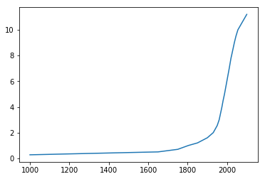

```python
plt.plot(years, population)
plt.show()
plt.close()
```

The function `plot(years, population)` tells the system that we want a chart where the horizontal axis (the $x$-axis) represents the numbers listed in `years`, while the vertical axis (the $y$-axis) represents the numbers listed in `population`. The function `show` then does the actual drawing. Finally, the function `close` cleans up the garbage left after all the computations needed to draw the chart.

The data is represented by a line. This is why such charts are called *line charts*.

Since this time we imported the entire library under the nickname `plt` the functions `plot`, `show` and `close` have to be addressed using both their "family name" (the library it comes from) and "first name": `plt.plot`, `plt.show` and `plt.close`.

Next, using the `title` function we shall give our chart a title:

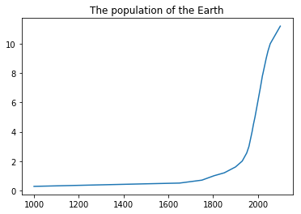

```python
plt.plot(years, population)
plt.title("The population of the Earth")
plt.show()
plt.close()
```

We can also put a label along the vertical axis to indicate that the numbers we are displaying are in billions. For this we need the function `ylabel` ("the label on the $y$-axis""):

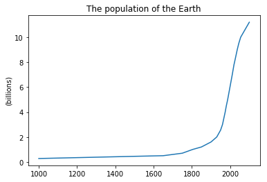

```python
plt.plot(years, population)
plt.title("The population of the Earth")
plt.ylabel("(billions)")
plt.show()
plt.close()
```

In conclusion: functions `plot`, `title` and `ylabel` add various elements to the chart, and only when all the elements have been added to the char we invoke the `show` function to do the actual drawing. After that we have to clean up by invoking the `close` function.

## 2.4. Exercises

**Exercise 1.** Look at the following code and then answer the questions:

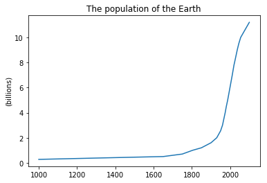

```python
import matplotlib.pyplot as plt
plt.plot(years, population)
plt.title("The population of the Earth")
plt.ylabel("(billions)")
plt.show()
plt.close()
```

1. What does `import ... as ..` do?
2. Why do we have to write `plt.plot`, and not simply `plot`?
3. What does `plot` do?
4. What do `title` and `ylabel` do?
5. What do `show` and `close` do?

**Exercise 2.** The following cell contains data about weight and length/height of a boy in the first seven years of his life.

```python
peroid    = ["6 m", "1.5 y", "2.5 y", "3.5 y", "4.5 y", "5.5 y", "6.5 y"]
weightKG  = [5.9,   11.5,    14.8,    20.5,    22.0,    24.2,    29.0   ]
heightCM  = [62.0,  84.0,    97.0,    115.0,   122.5,   131.5,   135.0  ]
```

Generate two charts: one to display how the weight of the boy changes over time, and the other one to display how the height of the boy changes over time.

For a boy from Exercise 2 visualize the way his BMI changed over time. The following Python program maight be helpful:

```python
BMI = [0, 0, 0, 0, 0, 0, 0]
for i in range(0, 7):
    BMI[i] = weightKG[i] / (heightCM[i] / 100.0)**2
```

**Exercise 4.** It is estimated that on July 1st, 2019 the population of China was 1,420,062,022. It is also estimated that the population of China increases by 0.35% per year. Visualize the population of China in the following ten years under the assumtion that these parameters will not change.

© 2019 [Petlja.org](https://petlja.org)